# Analysis of consequences of adverse weather events

Artem Shevlyakov

02/02/2019

## Synopsis

This document analyzes the data on adverse weather events in the USA in the years 1950-2011 and tries to outline the most harmful ones in respect to population health and economics. The analysis accounts for the frequency of event occurrence and its effects (i.e. damage, fatalities or injuries inflicted).

## Summary

The results show that, from the purely economical standpoint, floods and flash floods, tornadoes and hails present the most danger. Population health is mostly affected by excessive heat, flash floods and tornadoes. Both factors considered, flash floods and floods, and tornadoes, might be highlighted as most significant, as they occur regularly and inflict both massive infrastructure damage and a high number of injuries and fatalities. Several other events may inflict more damage or cause higher fatalities, but not both, and their irregularity lowers their overall significance as they cannot be accounted for properly.

## Data Processing

Before any analysis can be performed, all the required libraries and the data need to be loaded.

```r
library(data.table)
library(dplyr)
library(ggpubr)
library(ggplot2)
```

```r
if(!file.exists("stormdata.bz2")){
  download.file("https://d396qusza40orc.cloudfront.net/repdata%2Fdata%2FStormData.csv.bz2",
              "stormdata.bz2")
}
stormdata<-fread("stormdata.bz2")
```

The dataset is large. We’re going to extract only the columns we need for analysis and discard all the rest. Every single entry is going to be treated as a separate event. To perform the comparison, the data on the occurrence date, type of event and associated injury/fatality and damage statistics are required.

```r
stormsub <- select(stormdata, EVTYPE, BGN_DATE, FATALITIES, INJURIES, PROPDMG, PROPDMGEXP, CROPDMG, CROPDMGEXP)
rm(stormdata); gc()
```

```r
head(stormsub)
```

```
##     EVTYPE           BGN_DATE FATALITIES INJURIES PROPDMG PROPDMGEXP
## 1: TORNADO  4/18/1950 0:00:00          0       15    25.0          K
## 2: TORNADO  4/18/1950 0:00:00          0        0     2.5          K
## 3: TORNADO  2/20/1951 0:00:00          0        2    25.0          K
## 4: TORNADO   6/8/1951 0:00:00          0        2     2.5          K
## 5: TORNADO 11/15/1951 0:00:00          0        2     2.5          K
## 6: TORNADO 11/15/1951 0:00:00          0        6     2.5          K
##    CROPDMG CROPDMGEXP
## 1:       0
## 2:       0
## 3:       0
## 4:       0
## 5:       0
## 6:       0
```

Information on the extent of damage that is currently split into several columns needs to be joined. To do that, “K”/“M”/“B” notation should be converted into the actual numbers, and crop and property damage should be summarized.

After convertion, the value in the `DMGEXP` fields will indicate the factors of 10. We will only use the observations with the correct entries in the `DMGEXP` fields: that is, “K”, “M”, “B” or nothing at all.

The data should also be filtered so that only relevant records (i.e. resulting in at least one fatality/injury or property/crop damage) remain.

```r
stormsub <- stormsub %>%
    filter((grepl("[kKmMbB]", stormsub$PROPDMGEXP)|grepl("^$", stormsub$PROPDMGEXP))&
               (grepl("[kKmMbB]", stormsub$CROPDMGEXP)|grepl("^$", stormsub$CROPDMGEXP))) %>%
    filter(PROPDMG>0|CROPDMG>0|INJURIES>0|FATALITIES>0) %>%
    mutate(PROPDMGEXP=toupper(PROPDMGEXP),
           CROPDMGEXP=toupper(CROPDMGEXP)) %>%
    mutate(PROPDMGEXP=(as.numeric(factor(PROPDMGEXP, levels = c("","K","M","B"))
                                  )-1)*3,
           CROPDMGEXP=(as.numeric(factor(CROPDMGEXP, levels = c("","K","M","B"))
                                  )-1)*3) %>%
    mutate(PROPDMGABS=PROPDMG*10^PROPDMGEXP,
           CROPDMGABS=CROPDMG*10^CROPDMGEXP,
           TOTALDMG=PROPDMGABS+CROPDMGABS) %>%
    select(EVTYPE, BGN_DATE, FATALITIES, INJURIES, TOTALDMG)
head(stormsub)
```

```
##    EVTYPE           BGN_DATE FATALITIES INJURIES TOTALDMG
## 1 TORNADO  4/18/1950 0:00:00          0       15    25000
## 2 TORNADO  4/18/1950 0:00:00          0        0     2500
## 3 TORNADO  2/20/1951 0:00:00          0        2    25000
## 4 TORNADO   6/8/1951 0:00:00          0        2     2500
## 5 TORNADO 11/15/1951 0:00:00          0        2     2500
## 6 TORNADO 11/15/1951 0:00:00          0        6     2500
```

To better understand the dynamics, all the data shall be grouped by year.

```r
stormsub$BGN_DATE <- format(as.Date(stormsub$BGN_DATE, format="%m/%d/%Y %H:%M:%S"), "%Y")
eventbyyear <- dcast(as.data.table(stormsub),
                  BGN_DATE+EVTYPE~.,
                  value.var=c("TOTALDMG","INJURIES","FATALITIES"),
                  fun.aggregate=sum)
eventbyyear$EVCOUNT <- dcast(as.data.table(stormsub),
                 BGN_DATE+EVTYPE~.,
                 fun.aggregate = length)$.
head(eventbyyear)
```

```
##    BGN_DATE  EVTYPE  TOTALDMG INJURIES FATALITIES EVCOUNT
## 1:     1950 TORNADO  34481650      659         70     201
## 2:     1951 TORNADO  65505990      524         34     241
## 3:     1952 TORNADO  94102240     1915        230     233
## 4:     1953 TORNADO 596104700     5131        519     421
## 5:     1954 TORNADO  85805320      715         36     491
## 6:     1955 TORNADO  82660630      926        129     441
```

Since there are numerous types of reported events, we shall select the most dangerous ones. To do that, we will calculate the amount of damage, fatalities and injuries inflicted over the observation period, and select the top 10 events for each category.

```r
topdamage <- tapply(eventbyyear$TOTALDMG, eventbyyear$EVTYPE, FUN = sum)
topfatality <- tapply(eventbyyear$FATALITIES, eventbyyear$EVTYPE, FUN = sum)
topinjury <- tapply(eventbyyear$INJURIES, eventbyyear$EVTYPE, FUN = sum)
topdamage <- sort(topdamage, decreasing = TRUE)[1:10]
topfatality <- sort(topfatality, decreasing = TRUE)[1:10]
topinjury <- sort(topinjury, decreasing = TRUE)[1:10]

combined <- eventbyyear %>%
    filter(EVTYPE %in% names(topdamage) | EVTYPE %in% names(topinjury)|EVTYPE %in% names(topfatality)) %>%
    arrange(BGN_DATE, EVTYPE)
```

## Results

First, let’s see how frequent are the most destructive events that were selected earlier.

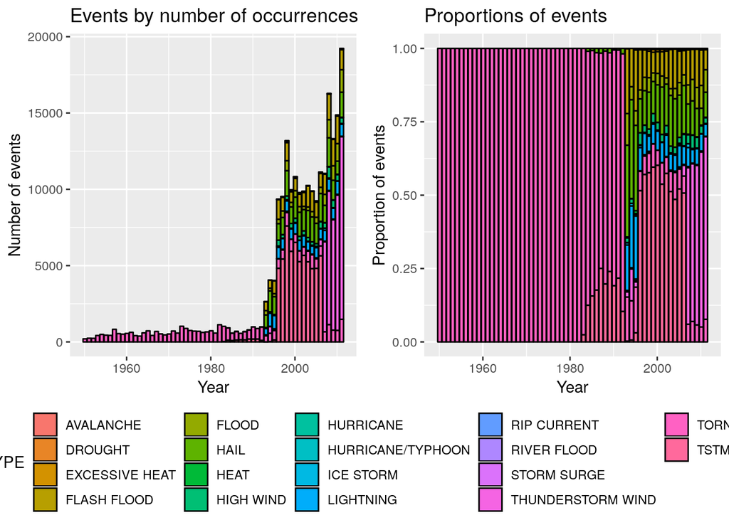

```r
p1 <- ggplot(data=combined,
             aes(x=as.Date(BGN_DATE, format="%Y"), y=EVCOUNT)) +geom_col(
                 aes(fill=EVTYPE), col='black') + labs(
                         title="Events by number of occurrences",
                         x="Year",
                         y="Number of events"
                     )
p2 <- ggplot(data=combined,
             aes(x=as.Date(BGN_DATE, format="%Y"), y=EVCOUNT)) +geom_col(
                 aes(fill=EVTYPE), col='black', position="fill") + labs(
                         title="Proportions of events",
                         x="Year",
                         y="Proportion of events"
                     )

ggarrange(p1, p2, ncol=2, common.legend = TRUE, legend="bottom")
```

```r
list(Fatalities=topfatality, Injuries=topinjury, Damage=topdamage)
```

```
## $Fatalities
##        TORNADO EXCESSIVE HEAT    FLASH FLOOD           HEAT      LIGHTNING
##           5630           1903            978            937            816
##      TSTM WIND          FLOOD    RIP CURRENT      HIGH WIND      AVALANCHE
##            504            470            368            246            224
##
## $Injuries
##           TORNADO         TSTM WIND             FLOOD    EXCESSIVE HEAT
##             91321              6957              6789              6525
##         LIGHTNING              HEAT         ICE STORM       FLASH FLOOD
##              5230              2100              1975              1777
## THUNDERSTORM WIND              HAIL
##              1488              1358
##
## $Damage
##             FLOOD HURRICANE/TYPHOON           TORNADO       STORM SURGE
##      150319678257       71913712800       57301935593       43323541000
##              HAIL       FLASH FLOOD           DROUGHT         HURRICANE
##       18733216230       17561538817       15018672000       14610229010
##       RIVER FLOOD         ICE STORM
##       10148404500        8967037810
```

Let’s plot a graph which will help us analyze the impact of weather on people’s health. Since the data from the 1990s onwards are much more complete, we are only going to use this time period. First let’s estimate a .975 quantile of fatalities and injuries to understand which boundaries to use for our graphs.

```r
injfataldata <- filter(combined, (EVTYPE=="TORNADO"|EVTYPE=="EXCESSIVE HEAT"|EVTYPE=="HEAT"|EVTYPE=="LIGHTNING"|EVTYPE=="FLASH FLOOD"|EVTYPE=="TSTM WIND")&BGN_DATE>=1990)
c("Injuries"=quantile(injfataldata$INJURIES, 0.975),
  "Fatalities"=quantile(injfataldata$FATALITIES, 0.975))
```

```
##   Injuries.97.5% Fatalities.97.5%
##          1743.20           308.25
```

For the ease of scaling, let’s use 2000 and 300 as our cutoff points for the graph.

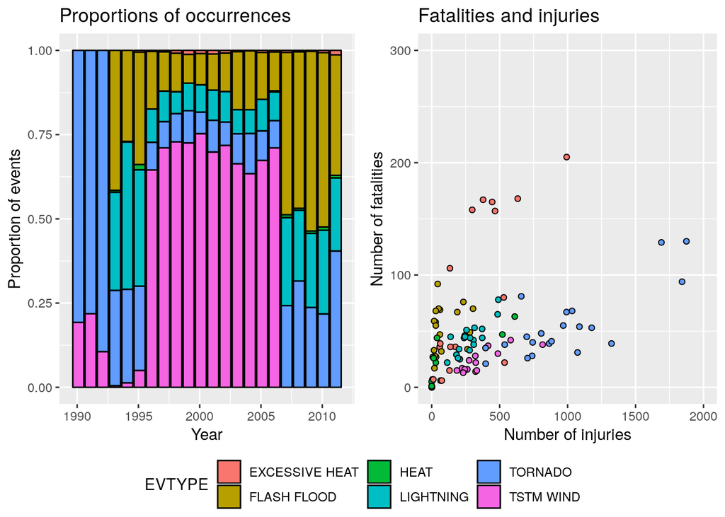

```r
p3 <- ggplot(data=injfataldata,
             aes(x=INJURIES, y=FATALITIES)) +geom_point(
                 aes(fill=EVTYPE), shape=21)+ theme(
                     legend.position = "bottom") + labs(
                         title="Fatalities and injuries",
                         x="Number of injuries",
                         y="Number of fatalities")+coord_cartesian(xlim=c(0,2000), ylim=c(0,300))
p4 <- ggplot(data=injfataldata,
             aes(x=as.Date(BGN_DATE, format="%Y"), y=EVCOUNT)) +geom_col(
                 aes(fill=EVTYPE), col='black', position="fill") + labs(
                         title="Proportions of occurrences",
                         x="Year",
                         y="Proportion of events"
                     )
ggarrange(p4, p3, ncol=2, common.legend = TRUE, legend="bottom")
```

A distinct pattern can be observed: heat and excessive heat result in a high number of deaths. Another disaster that tends to cause a lot of fatalities is flash flood, probably due to its suddenness. Tornadoes tend to inflict the most injuries.

The relative occurrences graph makes it clear that heat and excessive heat are relatively rare. However, tornadoes and flash floods form a significant share of reported adverse weather events each year.

Now let’s take a look at the economical impact produced by some of the most common and most destructive events (as established previously).

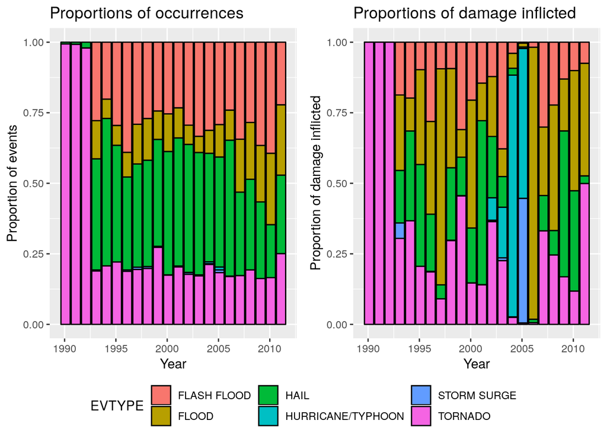

```r
damagedata <- filter(combined, (EVTYPE=="TORNADO"|EVTYPE=="FLOOD"|EVTYPE=="FLASH FLOOD"|EVTYPE=="HURRICANE/TYPHOON"|EVTYPE=="STORM SURGE"|EVTYPE=="HAIL")&BGN_DATE>=1990)
p5 <- ggplot(data=damagedata,
             aes(x=as.Date(BGN_DATE, format="%Y"), y=TOTALDMG)) +geom_col(
                 aes(fill=EVTYPE), col='black', position="fill") + labs(
                         title="Proportions of damage inflicted",
                         x="Year",
                         y="Proportion of damage inflicted"
                     )
p6 <- ggplot(data=damagedata,
             aes(x=as.Date(BGN_DATE, format="%Y"), y=EVCOUNT)) +geom_col(
                 aes(fill=EVTYPE), col='black', position="fill") + labs(
                         title="Proportions of occurrences",
                         x="Year",
                         y="Proportion of events"
                     )
ggarrange(p6, p5, ncol=2, common.legend = TRUE, legend="bottom")
```

As can be seen from the graph, tornadoes, floods and flash floods, and hails tend to occur very regularly and compose most of the reported events. These events inflict comparable shares of economical damage, with floods and flash floods on the higher end of the scale. Hurricanes and storm surges can cause spikes in the amount of losses, but, as said previously, they tend to be rare and do not carry the main economic burden.